# Edge q-labelling

- ND snaps are used to label PRN0 edges with *q*, a real value signifying a *temporal order* on edges.
  - *q* of an edge records the *q* (of the snapshot) where the edge *first* appears in an ND run.
  - Edge q-labels are distinct from edge contact probabilities, which are a function of *Q*, and is cumulative.
- Use the edge *q*-labels to order edges; such an ordering makes the *characteristic edge formation order* for an ND variant.

```python
import os
import numpy as np
import pandas as pd
import matplotlib.pyplot as plt
from sklearn.metrics import roc_curve
from sklearn.metrics import roc_auc_score as ras
```

```python
NDVs = ['c', 'x', 'r', 'a', 'y']
```

### Paci

- PRN0 edges are labelled by *avg_q*, and sorted on *avg_q* in increasing order.
- How effective are these *characteristic edge orderings* of ND variants in identifying TSE PRN0 edges (Paci dataset)?
  - Are PRN0 edges which are formed earlier (have smaller avg_q), more likely to be in TSE PRNs? This is a desirable outcome. Compare AUCs of ND variants.

```python
dirname = "Paci"
fn = os.path.join(dirname, 'P_frates.txt')
df = pd.read_table(fn, sep='\t')
PIDs = df.pid.tolist(); num_pids = len(PIDs); print(num_pids, PIDs)
SStypes = df.SStype.tolist(); print(SStypes)
```

```
10 ['1imq', '1lmb4', '1bf4', '2ptl', '2ci2', '1aps', '1fmk', '1bk2', '1shf', '1ten']
['a', 'a', 'ab', 'ab', 'ab', 'ab', 'b', 'b', 'b', 'b']
```

- Explore datafiles used and roll my own ROC.

```python
# example of datafiles used
pid = "1shf"
fn = os.path.join("Paci", pid + "_base_edge_features.out")
de = pd.read_table(fn, sep=' ')[['eid', 'sd', 'tse_prn_prob', 'tse_scn_prob']]
de.head()
```

|  | eid | sd | tse_prn_prob | tse_scn_prob |
| --- | --- | --- | --- | --- |
| 0 | 0 | 2 | 1.000000 | 0.000000 |
| 1 | 1 | 3 | 0.939394 | 0.636364 |
| 2 | 2 | 26 | 0.363636 | 0.000000 |
| 3 | 3 | 27 | 0.363636 | 0.000000 |
| 4 | 4 | 2 | 1.000000 | 0.000000 |

```python
dirn = os.path.join("P_NDH", "edv_a")
```

```python
fn = os.path.join(dirn, pid + "_edge_qlabels_x.out")
# file has an space at the end of each non-header line, pandas doesn't like this!
dq = pd.read_table(fn, sep=' ', skiprows=1, header=None).dropna(axis=1)
dq.columns = ['eid', 'x', 'y', 'sc0', 'avg_q', 'mode_q',
              'q1', 'q2', 'q3', 'q4', 'q5', 'q6', 'q7', 'q8', 'q9', 'q10']
dq.head()
```

|  | eid | x | y | sc0 | avg_q | mode_q | q1 | q2 | q3 | q4 | q5 | q6 | q7 | q8 | q9 | q10 |
| --- | --- | --- | --- | --- | --- | --- | --- | --- | --- | --- | --- | --- | --- | --- | --- | --- |
| 0 | 0 | 0 | 2 | 0 | 0.168 | 0.1 | 61 | 19 | 12 | 7 | 1 | 0 | 0 | 0 | 0 | 0 |
| 1 | 1 | 0 | 3 | 1 | 0.214 | 0.1 | 46 | 23 | 12 | 12 | 5 | 1 | 1 | 0 | 0 | 0 |
| 2 | 2 | 0 | 26 | 0 | 0.622 | 0.7 | 2 | 7 | 4 | 14 | 11 | 9 | 18 | 15 | 17 | 3 |
| 3 | 3 | 0 | 27 | 0 | 0.694 | 0.9 | 4 | 4 | 4 | 4 | 10 | 7 | 12 | 22 | 28 | 5 |
| 4 | 4 | 1 | 3 | 0 | 0.166 | 0.1 | 57 | 31 | 5 | 4 | 2 | 1 | 0 | 0 | 0 | 0 |

```python
# prep data for ROC
df = pd.DataFrame({'avg_q': dq.avg_q,
                   'tse_prn_prob': de.tse_prn_prob,
                   'TP': np.where(de.tse_prn_prob.values >= 0.5, 1, 0),
                   'FP': np.where(de.tse_prn_prob.values >= 0.5, 0, 1),})
df.head(10)
```

|  | avg_q | tse_prn_prob | TP | FP |
| --- | --- | --- | --- | --- |
| 0 | 0.168 | 1.000000 | 1 | 0 |
| 1 | 0.214 | 0.939394 | 1 | 0 |
| 2 | 0.622 | 0.363636 | 0 | 1 |
| 3 | 0.694 | 0.363636 | 0 | 1 |
| 4 | 0.166 | 1.000000 | 1 | 0 |
| 5 | 0.596 | 0.060606 | 0 | 1 |
| 6 | 0.645 | 0.515152 | 1 | 0 |
| 7 | 0.672 | 0.878788 | 1 | 0 |
| 8 | 0.784 | 0.030303 | 0 | 1 |
| 9 | 0.541 | 0.000000 | 0 | 1 |

```
120 204 324
```

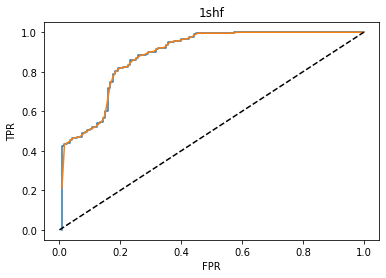

```python
#roll my own ROC
df = df.sample(frac=1.0) # shuffle rows
df.sort_values(by='avg_q', inplace=True)
max_x = df.FP.sum(); max_y = df.TP.sum() # for normalization
print(max_x, max_y, len(df))
dr = pd.DataFrame({'FPR': df.FP.cumsum().values/max_x,
                   'TPR': df.TP.cumsum().values/max_y})
plt.title(pid); plt.xlabel('FPR'); plt.ylabel('TPR')
plt.plot(dr.FPR.values, dr.TPR.values)
dg = dr.groupby('FPR').mean() # averaged, smoother curve
plt.plot(dg.index.values, dg.TPR.values)
plt.plot([0.0, 1.0], [0.0, 1.0], '--', color='black')
```

```python
# binary class only: roc_curve associates high scores(prob.) with positive label (1 by default)
# but our problem associates smaller avg_q with positive labels, so need to reverse/flip
y_true = df.TP.values; y_score = np.flip(df.avg_q.values) # must be sorted!
print(y_true.shape)
fpr, tpr, _ = roc_curve(y_true, y_score)
```

```
(324,)
```

```
0.884109477124183
```

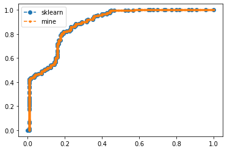

```python
# check roc_curve match with own ROC
plt.plot(fpr, tpr, 'o--', label='sklearn')
plt.plot(dr.FPR.values, dr.TPR.values, '.--', label='mine')
plt.legend()
print(ras(y_true, y_score))
```

```python
def plot_Paci_ROCs(tp_col:str, plt_title: str):
    fig, axes = plt.subplots(3, 4, figsize=(12, 9), constrained_layout=True)
    axes[2][2].remove(); axes[2][3].remove()
    plt.suptitle(plt_title, fontsize=14)
    AUCs = {} # keyed by pid
    for i, pid in enumerate(PIDs):
        r = i//4; c = i%4; ax = axes[r][c]
        fn = os.path.join(dirname, pid + "_base_edge_features.out")
        de = pd.read_table(fn, sep=' ')
        TP_labels = np.where(de[tp_col].values >= 0.5, 1, 0) # TP in eid order
        scores = []
        for j, ndv in enumerate(NDVs):
            fn = os.path.join(dirn, pid + "_edge_qlabels_" + ndv + ".out")
            dq = pd.read_table(fn, sep=' ', skiprows=1, header=None).dropna(axis=1)
            dq.columns = ['eid', 'x', 'y', 'sc0', 'avg_q', 'mode_q',
                          'q1', 'q2', 'q3', 'q4', 'q5', 'q6', 'q7', 'q8', 'q9', 'q10']
            df = pd.DataFrame({'avg_q': dq.avg_q, 'TP': TP_labels})
            df = df.sample(frac=1.0)
            df.sort_values(by='avg_q', inplace=True)
            y_true = df.TP.values; y_score = np.flip(df.avg_q.values)
            fpr, tpr, _ = roc_curve(y_true, y_score)
            auc = ras(y_true, y_score); scores.append(auc)
            ax.plot(fpr, tpr, label=ndv + ' ' + str(np.round(auc, 2)))
        AUCs[pid] = scores
        ax.set_title(pid)
        ax.plot([0.0, 1.0], [0.0, 1.0], '--', color='black')
        if 0==r: ax.set_xlabel("FPR", fontsize=14)
        if 0==c: ax.set_ylabel("TPR", fontsize=14)
        ax.legend(title='AUC'); ax.grid()
    aucs_df = pd.DataFrame.from_dict(AUCs, columns=NDVs, orient='index')
    return aucs_df
```